# Exploring the Behaviour Risk Survey data

## Setup

### Load packages

```r
library(ggplot2)
library(dplyr)
```

### Load and view the general structure of the given data

```r
load("Behavior_Risk.RData")
str(brfss2013)
```

```
## 'data.frame':    491775 obs. of  330 variables:
##  $ X_state  : Factor w/ 55 levels "0","Alabama",..: 2 2 2 2 2 2 2 2 2 2 ...
##  $ fmonth   : Factor w/ 12 levels "January","February",..: 1 1 1 1 2 3 3 3 4 4 ...
##  $ idate    : int  1092013 1192013 1192013 1112013 2062013 3272013 3222013 3042013 4242013 4242013 ...
##  $ imonth   : Factor w/ 12 levels "January","February",..: 1 1 1 1 2 3 3 3 4 4 ...
##  $ iday     : Factor w/ 31 levels "1","2","3","4",..: 9 19 19 11 6 27 22 4 24 24 ...
##  $ iyear    : Factor w/ 2 levels "2013","2014": 1 1 1 1 1 1 1 1 1 1 ...
##  $ dispcode : Factor w/ 2 levels "Completed interview",..: 1 1 1 1 1 1 1 1 1 1 ...
##  $ seqno    : int  2013000580 2013000593 2013000600 2013000606 2013000608 2013000630 2013000634 2013000644 2013001305 2013001338 ...
##  $ X_psu    : int  2013000580 2013000593 2013000600 2013000606 2013000608 2013000630 2013000634 2013000644 2013001305 2013001338 ...
##  $ ctelenum : Factor w/ 1 level "Yes": 1 1 1 1 1 1 1 1 1 1 ...
##  $ pvtresd1 : Factor w/ 2 levels "Yes","No": 1 1 1 1 1 1 1 1 1 1 ...
##  $ colghous : Factor w/ 1 level "Yes": NA NA NA NA NA NA NA NA NA NA ...
##  $ stateres : Factor w/ 1 level "Yes": 1 1 1 1 1 1 1 1 1 1 ...
##  $ cellfon3 : Factor w/ 1 level "Not a cellular phone": 1 1 1 1 1 1 1 1 1 1 ...
```

[output cut: 86 more lines]

## Part 1: About the data and scope of inference

### Based on the BRFSS user guide June-2013

### Objective of the Survey:

The objective behind this data collection is to get an insight on the preventive health factors and risk behaviours linked to chronic diseases for un-institutionalized adult U.S.A residents. This country wide survey named as ‘Behaviour risk factor surveillance system’ is conducted by the state department monthly in collaboration with the Centre of disease control (CDC) and an annual report is generated by CDC which publishes the result of the study and information on data quality. This survey captures behavioural information and disease prevalence that can affect the health status of adults. This captured data combined with the mortality and morbidity status can help federal officials make better decisions about their health-care related policies.

### Regarding Data collection:

The target population of this survey are adults who reside in private residences or college housing from each of the states of U.S.A, District of Columbia, Puerto Rico and the U.S Virgin islands who are contacted through landlines. According to the CDC calling Protocol, 20% of the interviews are conducted on weekdays and 80% of interviews are conducted on weekends and week-nights. According to the BRFSS survey protocol, an eligible household is considered as a housing unit that has a separate entrance, where occupants eat separately from other people on the property. Vacation homes not occupied by household members for more than 30 days are not considered as an eligible household.

### About the survey structure:

There is one core section wherein we screen-out people who may not be suitable for our study. At the end of the core-section, we arrive at the target audience and then roll out the rotating core, where we would ask about the demographics, Health-status and Health care access of the adult in either the private residence or college housing. Then, there is an optional core wherein the individual states can add their own questions to get additional information on their specific health-care priorities.

### Sample Design:

Once the target population is set, disproportionate stratified sampling is done and the landline numbers are randomly selected from two strata that are high density (which has a greater proportion of target numbers) and medium density (which has a comparatively lesser proportion of target numbers). The sampling rate of high density to medium density is 1:1.5. Data weighting is done to remove bias in the sample Geographic stratification was also thought about while designing the study but was later withdrawn due to the high costs involved.

### Scope of Inference and causality:

- This is a prospective observational study which relies on the data collected from the present survey. Hence, we cannot make any causal statements about the relationship between the response and explanatory variables that we select for this study
- This study uses random sampling, but we cannot generalize this to the population as there is a lot of bias involved
- One such bias is the non-responsive bias wherein we are unable to capture the information of adults who may be residing in a private residence or college housing but may not have a landline
- Another bias that has crept in is the voluntary response bias wherein only people with some strong opinion on health care related policies would oblige to take the survey
- This study also fails to account for the floating population of U.S.A. A person might be from California, but may have his career established in North Carolina recently. Hence, in this case we might not get authentic views on the state wide health care related issues from this person, as he has just moved in to the state

## Part 2: Research questions

**Research quesion 3:** It would be interesting to get an insight on the susceptibility of chronic diseases such as asthma which is a common lung disease among male and female respondents who are addicted to smoking. For this analysis, we split the population into males and females who have been diagnosed with asthma and addicted to smoking (Addiction to smoking is indicated by respondents who have been smoking at least 100 cigarettes in the past month)

## Part 3: Exploratory data analysis

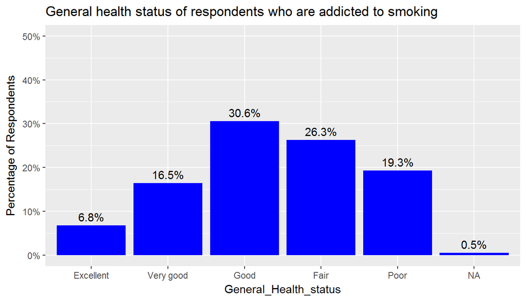

```r
# Filter out people who are addicted to tobacco(depicted by smoking 100 cigarretes and those who smoke everyday) and people who have sleep time of less than 6 hours
Respondents_addicted_to_tobacco<-brfss2013%>%filter((smoke100=="Yes")&(smokday2=="Every day"))%>%select(genhlth,bphigh4,sleptim1,bloodcho,smoke100,smokday2)
Respondents_addicted_to_tobacco_with_inadequate_sleep<-Respondents_addicted_to_tobacco%>%filter(sleptim1<6)
colnames(Respondents_addicted_to_tobacco_with_inadequate_sleep)<-c("General_Health_status")
plot1 <- ggplot(Respondents_addicted_to_tobacco_with_inadequate_sleep, aes(General_Health_status)) +
          geom_bar(aes(y = (..count..)/sum(..count..)),fill = "#0000FF") +
          scale_y_continuous(limits = c(0,0.5),labels=scales::percent) +
          ylab("Percentage of Respondents")+
          geom_text(aes( label = scales::percent((..count..)/sum(..count..) ),
                   y= (..count..)/sum(..count..) ), stat= "count", vjust = -.5)
print(plot1 + ggtitle("General health status of respondents who are addicted to smoking"))
```

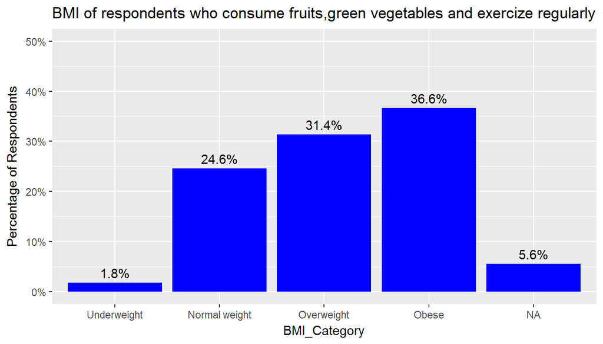

```r
brfss2013$fruit1<-as.numeric(brfss2013$fruit1)
brfss2013$fvgreen<-as.numeric(brfss2013$fvgreen)
brfss2013$exerany2<-as.numeric(brfss2013$exerany2)
Respondents_eating_fruits_regularly<-brfss2013%>%filter(fruit1>4)
Respondents_eating_vegetables_regularly<-Respondents_eating_fruits_regularly%>%filter(fvgreen>4)
Respondents_exercizing_Regularly<-Respondents_eating_vegetables_regularly%>%filter(exerany2>1)
Respondents_exercizing_Regularly<-Respondents_exercizing_Regularly%>%select(genhlth,X_bmi5cat)
colnames(Respondents_exercizing_Regularly)<-c("General_Health","BMI_Category")
plot2 <- ggplot(Respondents_exercizing_Regularly, aes(BMI_Category)) +
          geom_bar(aes(y = (..count..)/sum(..count..)),fill = "#0000FF") +
          scale_y_continuous(limits=c(0,0.5),labels=scales::percent) +
          ylab("Percentage of Respondents")+
          geom_text(aes( label = scales::percent((..count..)/sum(..count..) ),
                   y= (..count..)/sum(..count..) ), stat= "count", vjust = -.5)
print(plot2 + ggtitle("BMI of respondents who consume fruits,green vegetables and exercize regularly"))
```

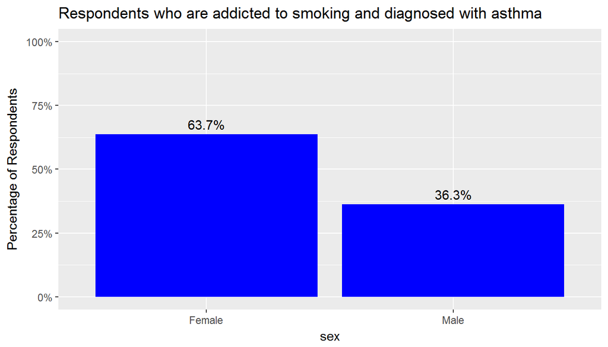

```r
#table(brfss2013$smoke100)
Respondents_smoked<-brfss2013%>%filter(smoke100=="Yes"&asthma3=="Yes")%>%select(sex)
Respondents_smoked$sex=as.character(Respondents_smoked$sex)
Respondent_Summary<-Respondents_smoked%>%group_by(sex)%>%summarise(Respondent_sex=n())%>%mutate(labels=paste0(round((Respondent_sex/sum(Respondent_sex))*100,1),"%"))
plot3 <- ggplot(Respondents_smoked, aes(sex)) +
          geom_bar(aes(y = (..count..)/sum(..count..)),fill = "#0000FF") +
          scale_y_continuous(limits=c(0,1.0),labels=scales::percent) +
          ylab("Percentage of Respondents")+
          geom_text(aes( label = scales::percent((..count..)/sum(..count..) ),
                   y= (..count..)/sum(..count..) ), stat= "count", vjust = -.5)
print(plot3+ ggtitle("Respondents who are addicted to smoking and diagnosed with asthma"))
```